# MPDW IPM

# Data

Data yang digunakan adalah data deret waktu Indeks Pembangunan Manusia (IPM) Provinsi Jawa Barat dari tahun 2010-2024 (15 periode).

```r
library(readxl)
dt_ipm <- read_excel("C:/Users/MUTIARA ARDIANA/OneDrive/Desktop/SEMESTER 5/[3] MPDW/2 MPDW/Data IPM Jabar.xlsx", sheet = 1)
dt_ipm
```

```
## # A tibble: 15 × 2
##    tahun   IPM
##    <dbl> <dbl>
##  1  2010  66.2
##  2  2011  66.7
##  3  2012  67.3
##  4  2013  68.2
##  5  2014  68.8
##  6  2015  69.5
##  7  2016  70.0
##  8  2017  70.7
##  9  2018  71.3
## 10  2019  72.0
## 11  2020  72.1
## 12  2021  72.4
## 13  2022  73.1
## 14  2023  73.7
## 15  2024  74.4
```

# Model Awal

```r
library(lmtest)
model_awal <- lm(IPM ~ tahun, data = dt_ipm)
summary(model_awal)
```

```
##
## Call:
## lm(formula = IPM ~ tahun, data = dt_ipm)
##
## Residuals:
##      Min       1Q   Median       3Q      Max
## -0.30876 -0.21933 -0.06833  0.20545  0.43095
##
## Coefficients:
##               Estimate Std. Error t value Pr(>|t|)
## (Intercept) -1.099e+03  3.013e+01  -36.47 1.76e-14 ***
## tahun        5.799e-01  1.494e-02   38.81 7.91e-15 ***
## ---
## Signif. codes:  0 '***' 0.001 '**' 0.01 '*' 0.05 '.' 0.1 ' ' 1
##
## Residual standard error: 0.25 on 13 degrees of freedom
## Multiple R-squared:  0.9914, Adjusted R-squared:  0.9908
## F-statistic:  1506 on 1 and 13 DF,  p-value: 7.908e-15
```

Nilai **Adjusted R-squared** sangat tinggi **(0.9908)** dan koefisien tahun sangat signifikan **(p-value < 0.001)**.

## Uji Autokorelasi

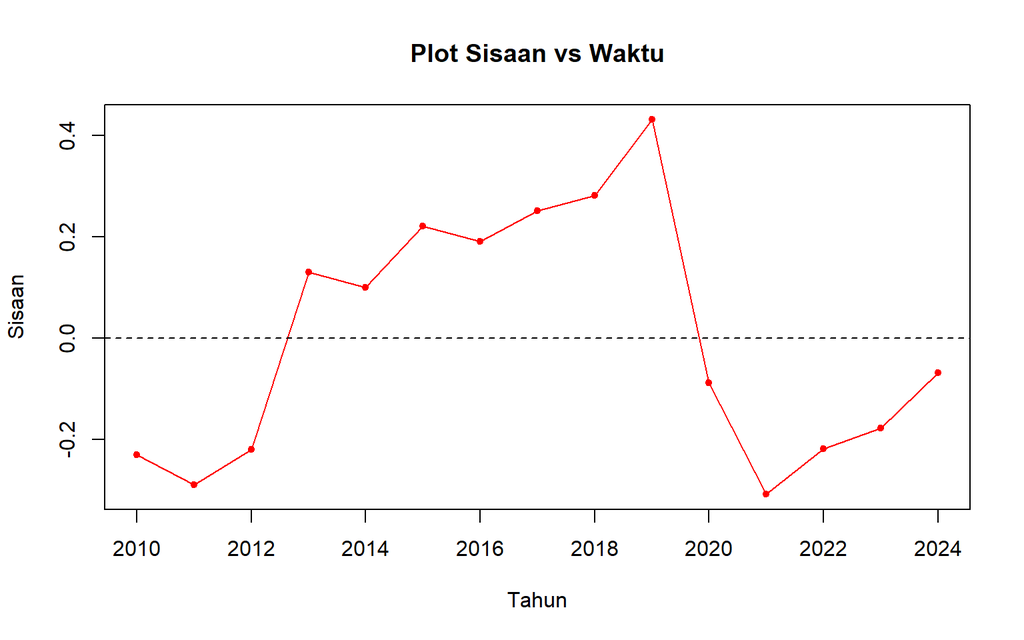

```r
# Ambil sisaan dari model
sisaan_awal <- residuals(model_awal)

# Plot sisaan terhadap waktu
plot(dt_ipm$tahun, sisaan_awal, type="o", pch=20, col="red",
     main="Plot Sisaan vs Waktu", xlab="Tahun", ylab="Sisaan")
abline(h=0, lty=2)
```

```r
dwtest(model_awal)
```

```
##
##  Durbin-Watson test
##
## data:  model_awal
## DW = 0.63367, p-value = 0.0001574
## alternative hypothesis: true autocorrelation is greater than 0
```

Berdasarkan hasil Durbinn Watson diatas, dapat dilihat bahwa:

- p-value yang dihasilkan **sangat kecil (0.0001574)**, yaitu di bawah tingkat signifikansi 0.05.
- Kesimpulan: **menolak H0**, sehingga model **terbukti menderita autokorelasi**.

# Penanganan Autokorelasi

## Metode 1: Cochrane Orcutt

```r
library(orcutt)
model_co <- cochrane.orcutt(model_awal)
summary(model_co)
```

```
## Call:
## lm(formula = IPM ~ tahun, data = dt_ipm)
##
##                Estimate  Std. Error t value  Pr(>|t|)
## (Intercept) -1.0458e+03  7.0663e+01 -14.800 4.529e-09 ***
## tahun        5.5349e-01  3.4992e-02  15.818 2.115e-09 ***
## ---
## Signif. codes:  0 '***' 0.001 '**' 0.01 '*' 0.05 '.' 0.1 ' ' 1
##
## Residual standard error: 0.1815 on 12 degrees of freedom
## Multiple R-squared:  0.9542 ,  Adjusted R-squared:  0.9504
## F-statistic: 250.2 on 1 and 12 DF,  p-value: < 2.115e-09
##
## Durbin-Watson statistic
## (original):    0.63367 , p-value: 1.574e-04
## (transformed): 1.74572 , p-value: 2.041e-01
```

```r
# rho paling optimum
rho <- model_co$rho
cat("Rho optimum:", rho)
```

```
## Rho optimum: 0.6560223
```

**Hasil Penanganan (C-O):**

- Lihat statistik **Durbin-Watson baru**. Nilainya sekarang jauh lebih dekat ke 2, dan p-value-nya (> 0.05) menunjukkan bahwa **autokorelasi sudah berhasil diatasi**.
- Intersept: **-1045,8**
- Slope: **0,55348**

### Secara Manual

```r
ipm.trans <- dt_ipm$IPM[-1] - dt_ipm$IPM[-15]*rho

tahun.trans <- dt_ipm$tahun[-1] - dt_ipm$tahun[-15]*rho
model_co_manual <- lm(ipm.trans~tahun.trans)

b0_co_manual <- coef(model_co_manual)[1]/(1-rho)
b1_co_manual <- coef(model_co_manual)[2]
cat("Koefisien manual Cochrane-Orcutt:\n")
```

```
## Koefisien manual Cochrane-Orcutt:
```

```r
cat("b0:", b0_co_manual, "\n")
```

```
## b0: -1045.839
```

```r
cat("b1:", b1_co_manual, "\n")
```

```
## b1: 0.5534855
```

## Metode 2: Hildreth-Lu

```r
library(HoRM)
hildreth.lu.func<- function(r, model){
  x <- model.matrix(model)[,-1]
  y <- model.response(model.frame(model))
  n <- length(y)
  t <- 2:n
  y <- y[t]-r*y[t-1]
  x <- x[t]-r*x[t-1]

  return(lm(y~x))
}

#Pencariab rho yang meminimumkan SSE
r <- c(seq(0.1,0.9, by= 0.1))
tab <- data.frame("rho" = r, "SSE" = sapply(r, function(i){deviance(hildreth.lu.func(i, model_awal))}))
round(tab, 4)
```

```
##   rho    SSE
## 1 0.1 0.6448
## 2 0.2 0.5632
## 3 0.3 0.4977
## 4 0.4 0.4484
## 5 0.5 0.4151
## 6 0.6 0.3980
## 7 0.7 0.3971
## 8 0.8 0.4122
## 9 0.9 0.4435
```

Berdasarkan hasil di atas, terlihat ρ minimum ketika 0.7. Namun, hasil tersebut masih kurang teliti sehingga akan dicari kembali ρ yang lebih optimum dengan ketelitian yang lebih. Jika sebelumnya jarak antar ρ yang dicari adalah 0.1, kali ini jarak antar ρ adalah 0.001 dan dilakukan pada selang 0.5 sampai dengan 0.8.

```r
#Rho optimal di sekitar 0.6
rOpt <- seq(0.5,0.8, by= 0.001)
tabOpt <- data.frame("rho" = rOpt, "SSE" = sapply(rOpt, function(i){deviance(hildreth.lu.func(i, model_awal))}))
head(tabOpt[order(tabOpt$SSE),])
```

```
##       rho       SSE
## 157 0.656 0.3955105
## 158 0.657 0.3955113
## 156 0.655 0.3955114
## 159 0.658 0.3955137
## 155 0.654 0.3955138
## 160 0.659 0.3955177
```

Hasil: Terlihat bahwa ρ optimum yang meminimalkan SSE adalah **0.656**

### Plot SSE Optimum

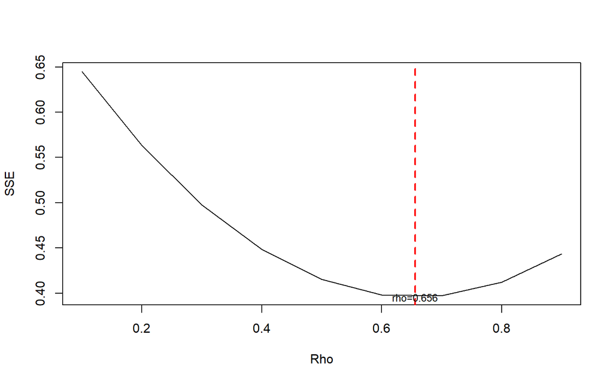

```r
par(mfrow = c(1,1))
plot(tab$SSE ~ tab$rho , type = "l", xlab = "Rho", ylab = "SSE")
abline(v = tabOpt[tabOpt$SSE==min(tabOpt$SSE),"rho"], lty = 2, col="red",lwd=2)
text(x=0.656, y=0.3955105, labels = "rho=0.656", cex = 0.8)
```

```r
model_hl <- hildreth.lu(dt_ipm$IPM, dt_ipm$tahun, rho = 0.656)
summary(model_hl)
```

```
##
## Call:
## lm(formula = y ~ x)
##
## Residuals:
##      Min       1Q   Median       3Q      Max
## -0.36218 -0.07714  0.01530  0.10784  0.24710
##
## Coefficients:
##               Estimate Std. Error t value Pr(>|t|)
## (Intercept) -359.76988   24.30650  -14.80 4.53e-09 ***
## x              0.55349    0.03499   15.82 2.11e-09 ***
## ---
## Signif. codes:  0 '***' 0.001 '**' 0.01 '*' 0.05 '.' 0.1 ' ' 1
##
## Residual standard error: 0.1815 on 12 degrees of freedom
## Multiple R-squared:  0.9542, Adjusted R-squared:  0.9504
## F-statistic: 250.2 on 1 and 12 DF,  p-value: 2.114e-09
```

```r
#Transformasi Balik
cat("y = ", coef(model_hl)[1]/(1-0.656), "+", coef(model_hl)[2],"x", sep = "")
```

```
## y = -1045.843+0.5534873x
```

```r
#Deteksi autokorelasi
dwtest(model_hl)
```

```
##
##  Durbin-Watson test
##
## data:  model_hl
## DW = 1.7457, p-value = 0.2041
## alternative hypothesis: true autocorrelation is greater than 0
```

# Evaluasi Akhir

```r
# Menghitung SSE untuk setiap model secara manual
sse_awal <- sum(residuals(model_awal)^2)
sse_co <- sum(residuals(model_co)^2)
sse_hl <- sum(residuals(model_hl)^2)

# Membuat tabel perbandingan
data.frame(
  Metode = c("Model Awal", "Cochrane-Orcutt", "Hildreth-Lu"),
  SSE = c(sse_awal, sse_co, sse_hl),
  DW_Statistic = c(dwtest(model_awal)$statistic, model_co$DW[3], dwtest(model_hl)$statistic)
)
```

```
##            Metode       SSE DW_Statistic
## 1      Model Awal 0.8124876    0.6336663
## 2 Cochrane-Orcutt 1.1632834    1.7457153
## 3     Hildreth-Lu 0.3955105    1.7456817
```

**Kesimpulan:**

- Model Hildreth-Lu lebih akurat karena berhasil menurunkan SSE model, sementara model Cochrane-Orcutt menaikan SSE model.
- Keduanya juga berhasil menghilangkan autokorelasi, yang ditunjukkan oleh statistik DW yang mendekati 2.
- Berdasarkan hasil, estimasi koefisien dan uji signifikansi pada model akhir Hildreth-Lu jauh lebih dapat dipercaya.